# Modeling data generating processes

We’ll primarily deal with systems of continuous random variables that are normal or approximately normal and are linearly related to each other. Such a system is then jointly a multivariate normal distribution.

For example, we may specify the **distribution** of a system as:

1. $$\begin{align*}
   X &= 100 + \epsilon_X \\
   Y &= 4 + \frac{1}{60}X + \epsilon_Y \\
   \epsilon_X &\sim Norm(0, 15^2)\\
   \epsilon_Y &\sim Norm(0, 1)
   \end{align*}$$

Each variable is written in terms of a linear combination of some other variables (or none) plus a constant intercept and a normal error term.

Note that in (A), X is defined on its own and Y is defined in terms of X. In (B), we have the reverse and X is defined in terms of Y.

We can confirm that (A) and (B) have the same joint distribution via simulation:

```r
# Set a RNG seed, so our simulations will give the same results every time we run our code
set.seed(2413)
# The number of samples we'll use for our simulations. Fairly high for more accurate
# estimation of means and variances/covariances.
n <- 100000
#
eps_X.A <-rnorm(n, 0, 15) # Draw n random samples from a normal distribution with mean=0, standard deviation=15
eps_Y.A <- rnorm(n, 0, 1)
X.A <- 100 + eps_X.A
Y.A <- 4 + X.A/60 + eps_Y.A
#
eps_X.B <- rnorm(n, 0, sqrt(60^2/17))
eps_Y.B <- rnorm(n, 0, sqrt(17/16))
Y.B <- 17/3 + eps_Y.B
X.B <- 80 + 60*Y.B/17 + eps_X.B
#
# Compute means (mu.A and mu.B) and covariance matrices (cov.A and cov.B)
mu.A <- sapply(list(X.A=X.A, Y.A=Y.A), mean)
cov.A <- cov(cbind(X.A, Y.A))
#
mu.B <- sapply(list(X.B=X.B, Y.B=Y.B), mean)
cov.B <- cov(cbind(X.B, Y.B))
```

```r
mu.A
```

```
       X.A        Y.A
100.060492   5.670453
```

```r
mu.B
```

```
      X.B       Y.B
99.913768  5.667818
```

```r
cov.A
```

```
           X.A      Y.A
X.A 223.756791 3.722121
Y.A   3.722121 1.060153
```

```r
cov.B
```

```
           X.B      Y.B
X.B 224.352701 3.727076
Y.B   3.727076 1.063201
```

As we can see, the means and the covariance matrices for X and Y in (A) and (B) are in fact equal (up to expected noise in the sample), even though the code is different and the order in which X and Y are computed is reversed. Plotting them further confirms this:

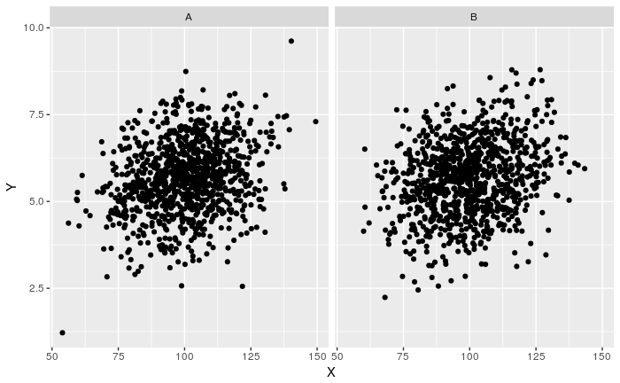

```r
library(ggplot2)
nDisp <- 1000
ix <- 1:nDisp
df <- data.frame(X = c(X.A[ix], X.B[ix]), Y = c(Y.A[ix], Y.B[ix]),
                 model = factor(c(rep('A', nDisp), rep('B', nDisp))))
#
ggplot(df, aes(X, Y)) +
  geom_point() +
  facet_grid(. ~ model)
```

Let’s suppose that this isn’t just simulated data but that this describes some real world interaction. For example, if X represents someone’s IQ and Y represents their log yearly income.

If our goal is strictly **prediction**, that is, we have observations of X and want to make a prediction about Y or vice versa then it doesn’t really matter whether we’re using (A) or (B). One or the other may be more convenient depending on which variable we’re trying to predict, but each entails the same joint distribution for X and Y and contains all the information we need to make any prediction. That is, the conditional PDFs for X and Y are the same for both (A) and (B).

$$\begin{align*}
f_A(x\,|\,y) &= f_B(x\,|\,y) \\
f_A(y\,|\,x) &= f_B(y\,|\,x)
\end{align*}$$

If our goal is to predict how a variable changes if we **intervene** on the system we’re studying and alter another variable, merely knowing the joint distribution is insufficient. Interventions are not the same as making observations. They don’t just determine the value of a variable, they change the system’s distribution. Understanding how they do absolutely requires understanding the causal relationships between variables.

In this series, we’ll use such sets of equations as (A) and (B) not just to define distributions but simultaneously the **data generating process** behind the distributions. We’ll interpret an equals sign not just as saying that the left and right hands sides are algebraically equal, but that in the data generating process any variables in the right hand side are referenced in the process of determining the variable on the left hand side. That is, there is a causal effect from the right hand side to the left hand side.

As an example of an intervention and how a model of the data generating process would help, suppose we want to know what effect increasing a population’s income has on IQ. Let’s use model (A) to answer the question. Here that is again:

1. $$\begin{align*}
   X &= 100 + \epsilon_X \\
   Y &= 4 + \frac{1}{60}X + \epsilon_Y \\
   \epsilon_X &\sim Norm(0, 15^2)\\
   \epsilon_Y &\sim Norm(0, 1)
   \end{align*}$$

We’ll model the intervention by reaching in and tweaking our system by fixing log income (Y) to be a specific high value, perhaps twenty. That is, an income of $\$10^{20}$ per year. That’s a lot.

($A_{Y=20}$)
$$\begin{align*}
X_{Y=20} &= 100 + \epsilon_X \\
Y_{Y=20} &= 20 \\
\epsilon_X &\sim Norm(0, 15^2)
\end{align*}$$

We’ll use the notation of a subscript Y=20 on the model and on the variables to indicate we made an intervention, as this is a fundamentally different data generating process and different random variables.

You can tell what happened to IQ easily enough by inspection. However, since it’s so easy, we’ll go ahead and directly instantiate this new data generating process in code.

```r
eps_X.A <-rnorm(n, 0, 15)
X.A.y.20 <- 100 + eps_X.A
Y.A.y.20 <- rep(20, n)
#
mu.A.y.20 <- sapply(list(X.A.y.20=X.A.y.20, Y.A.y.20=Y.A.y.20), mean)
cov.A.y.20 <- cov(cbind(X.A.y.20, Y.A.y.20))
```

```r
mu.A.y.20
```

```
X.A.y.20 Y.A.y.20
100.0078  20.0000
```

```r
cov.A.y.20
```

```
         X.A.y.20 Y.A.y.20
X.A.y.20 224.3259        0
Y.A.y.20   0.0000        0
```

We’re again left with a constant Y and a normal X, but it looks like we’ll have a different mean and variance for X. Rather than finishing our arithmetic, let’s just run the new code and see the results.

```r
eps_X.B <- rnorm(n, 0, sqrt(60^2/17))
Y.B.y.20 <- rep(20, n)
X.B.y.20 <- 80 + 60*Y.B.y.20/17 + eps_X.B
#
mu.B.y.20 <- sapply(list(X.B.y.20=X.B.y.20, Y.B.y.20=Y.B.y.20), mean)
cov.B.y.20 <- cov(cbind(X.B.y.20, Y.B.y.20))
```

```r
mu.B.y.20
```

```
X.B.y.20 Y.B.y.20
150.5956  20.0000
```

```r
cov.B.y.20
```

```
         X.B.y.20 Y.B.y.20
X.B.y.20 211.8945        0
Y.B.y.20   0.0000        0
```

We’re looking at a mean of about 150 and a variance of about 210 (as opposed to $15^2=225$) for X (IQ) now. Model (B) makes the prediction that intervening to increase income will increase IQ. We wouldn’t expect this in reality, and so we should prefer model (A).

Intervention is not in general equivalent to conditioning on observations, but that may sometimes be the case depending on the model. Intervention on Y is different from observing Y for model (A), but they’re the same for model (B). Writing this in terms of PDFs:

$$\begin{align*}
f_A(x_y) &\neq f_A(x\,|\,y) \\
f_B(x_y) &= f_B(x\,|\,y)
\end{align*}$$

The opposite is true for interventions and observations of X.

$$\begin{align*}
f_A(y_x) &= f_A(y\,|\,x) \\
f_B(y_x) &\neq f_B(y\,|\,x)
\end{align*}$$

In the case of (A) and (B), intervention and conditioning on observations are different precisely when an intervention would “cut” the connection between X and Y because this dependence is built into the equation that is overwritten. For example when $Y = 4 + \frac{1}{60}X + \epsilon_Y$ is replaced with $Y = 20$, the X term disappears from the equation for Y.

In the next post, we’ll introduce a way to represent these causal dependencies between variables seperately from the precise details of the distributions.